# Colocalization of Height GWAS Locus and ATP13A2 eQTL

Misa Graff

June 10, 2024, 19:14

# Colocalización genética

La colocalización genética es un método estadístico que identifica factores genéticos compartidos entre dos o más rasgos en un locus específico. Puede ayudar a descubrir variantes causales superpuestas que causan fenotipos de enfermedades complejas o moleculares. Por ejemplo, si la señal en un locus genético determinado para un rasgo y el nivel de expresión génica se colocalizan, esto podría indicar el papel de un gen en la causa de la enfermedad. Otro ejemplo, si las señales para el nivel de proteína y el nivel de expresión génica se colocalizan, esto podría indicar el papel de un gen en la producción de esa proteína. Un tercer ejemplo, si las señales en un locus dado para dos rasgos (por ejemplo, presión sanguínea y enfermedad coronaria) se colocalizan, esto podría indicar el papel de este locus genético en ambos rasgos juntos (en este ejemplo, la presión sanguínea afecta a la enfermedad coronaria).

En este wrokshop vamos a utilizar un paquete de R llamado ‘coloc’ para observar las señales de un locus genético para dos rasgos, proteínas o niveles de expresión diferentes y ver si se colocalizan.

## 0. Preparación de R

```r
# Limpiamos el ambiente dentro de R.
rm(list = ls(all = TRUE))
```

Para los análisis en este documento se utilizan los paquetes `coloc` y `Rfast`. El primero tiene funciones para llevar a cabo pruebas de colocalización, carga a su vez `ggplot2`, `data.table` y otros paquetes adicionales. `Rfast` tiene una serie de funciones para el análisis de datos, como regresiones lineal y logísticas, y obtener estadísticas descriptivas.

Podemos instalarlos con los siguientes comandos:

```r
install.packages("coloc")
install.packages("Rfast")
```

Para cargar los paquetes de *R* utilizamos los siguientes comandos:

```r
library("coloc")
library("Rfast")
```

## 1. Lectura y preparación de los datos análisis

Como hemos mencionado con anterioridad, para llevar a cabo el análisis de colocalización vamos a utilizar el paquete `coloc`. Los argumentos que requiere este paquete para trabajar son los siguientes:

- `file1` Archivo GWAS 1, asumidos como eQTLs para un transcrito.
- `file2` Archivo GWAS 2, estadísticas descriptivas de un GWAS.
- `trait1` Rasgo 1, puede ser el nombre de un gen.
- `trait1` Rasgo 2, fenotipo del GWAS.

Para correr el primer ejemplo de colocalización tenemos que asignar los valores a cada uno de los argumentos a usar en nuestras funciones.

```
##  Archivo de GWAS 1:
##  file1 <- "ENSG00000159363.17.GTEx.eqtl.txt"
```

```
## Archivo de GWAS 2:
##  file2 <- "Height_HIS.GWAS.ENSG00000159363.coloc.input"
```

```
##  Rasgo 1:
##  trait1 <- "ENSG00000159363"
```

```
## Rasgo 2:
##  trait2 <- "height"
```

Para seguir con el análisis, necesitamos establecer el **directorio de trabajo**. Necesitamos establecer ya que es ahí donde vamos a centralizar nuestro trabajo, vamos a guardar los outputs que generemos, los resultados de nuestros análisis, y gráficos. Antes que nada, para saber cuál es nuestro directorio de trabajo actual usamos `getwd()`:

```r
getwd()
```

```
## [1] "~/home/user"
```

Ahora que sabemos en qué directorio estamos vamos a generar un folder (o directorio) donde vamos a trabajar. Podemos hacerlo de varias formas: manualmente con el explorador de archivos, directamente en la terminal con `mkdir`, o con `dir.crate()`. Para los últimos dos necesitamos la **ruta** hacia el nuevo directorio.

```r
# Esta función sólo requiere el nombre del nuevo directorio.
dir.create("coloc")
```

Para poder crearlo desde la terminal usamos el comando `mkdir`:

```r
# Podemos correrlo directamente en R
system('mkdir coloc')       # El comando `system()` realiza un comando en el sistema.
```

O podemos hacerlo directamente en la terminal:

```bash
mkdir coloc
```

Establecemos un nuevo directorio de trabajo con `setwd()`. Indicamos la nueva **ruta** del nuevo directorio de trabajo:

```r
setwd("coloc")
```

Ya que estamos en nuestro **directorio de trabajo** podemos seguir con nuestro trabajo. El primer paso a realizar es importar la tabla con los datos de resumen estadísticos de la región (gwas1/eqtls).

**Antes de cargar nuestros datos, es necesario saber dónde están.** Para este taller podemos acceder a nuestra información desde la ruta *“/storage/workshops/colocalization-workshop/”*. Para hacer más sencillo el cargar la información, generamos un objeto con esta data.

```r
# Los datos para este workshop se encuentran en otra parte del servidor, para acceder a esto
data_path <- "/storage/workshops/colocalization-workshop/"

# Para cargar los datos usamos la función "paste0()", que sirve para juntar dos strings.
# En este caso, el nombre del archivo y dónde se localiza. Por ejemplo:
paste0(data_path, file1)
```

[output not shown]

```r
# NOTA: Hay otra función similar a `paste0()`, esta es `paste()`. Son identicas
# en su función, (las dos juntan strings), la única diferencia es que `paste()`
# pone un espacio entre los strings, mientras que `paste0()` los ignora.

paste("a", "b", "c")
```

```
## [1] "a b c"
```

```r
paste0("a", "b", "c")
```

```
## [1] "abc"
```

```r
eqtl <- read.table(paste0(data_path, file1),     # eQTLs
                   header = T,                   # Indica que la tabla tiene nombres de las variables
                   stringsAsFactors = F)         # Especifica si variables tipo caracter se
                                                 # transforman a tipo factor
```

Importamos los datos de estadísticas descriptivas del gwas2.

```r
gwas <- read.table(paste0(data_path, file2),     # Estadisticas descriptivas
                   header = T,                   # La tabla tiene nombres de las variables
                   stringsAsFactors = F)         # Especifica si variables tipo caracter se
                                                 # transforman a tipo factor
```

Asignamos nombres a las filas de cada una de las tablas para poder compararlas. Estos nombres deben ser únicos.

```r
rownames(eqtl) <- eqtl$rsID
rownames(gwas) <- gwas$MarkerName
```

Después de importar los datos a nuestra área de trabajo y prepararla, podemos revisar que haya variables significativas en el GWAS.

```r
# Is there a suggestive signal in GWAS2?

if (dim(gwas[which(gwas$p_value < 1e-5),])[1] > 0){
  cat(" ¿Existe una señal sugerente en GWAS2 (P < 1e-5)?", "\n",
      "Sí, sí existe una señal sugerente.", "\n\n")
  } else {
  cat(" ¿Existe una señal sugerente en GWAS2 (P < 1e-5)?", "\n",
      "No se identificó ninguna señal.", "\n\n")
    }
```

```
##  ¿Existe una señal sugerente en GWAS2 (P < 1e-5)?
##  Sí, sí existe una señal sugerente.
```

```r
#is there a significant signal in GWAS2?

if(dim(gwas[which(gwas$p_value < 5e-8),])[1]>0){
  cat(" ¿Existe una señal significativa en GWAS2 (P < 5e-8)?", "\n",
      "Sí, sí existe una señal significativa.", "\n\n")
  } else {
  cat(" ¿Existe una señal significativa en GWAS2 (P < 5e-8)?", "\n",
      "No se identificó ninguna señal significativa.", "\n\n")
  }
```

```
##  ¿Existe una señal significativa en GWAS2 (P < 5e-8)?
##  Sí, sí existe una señal significativa.
```

A continuación, vamos a crear una lista con los nombres de cada RSID (Reference SNP cluster ID) que están en tabla del GWAS. Quedándonos sólo con las variantes que tienen un valor de P válido.

```r
# Hacemos match entre el RSID de la base de datos del GWAS y el del eQTL.
eqtl <- eqtl[gwas$MarkerName, ]

# Eliminamos todos los valores que tienen NA (Missing) en el valor de P.
eqtl <- eqtl[which(!is.na(eqtl$pval_asc)), ]
```

Hasta el momento, nuestros archivos se deben ver de esta forma:

eQTL Table

|  | phenotype_id | variant_id | tss_distance | REF | ALT | maf_trc | beta_asc | beta_se_asc | tstat_asc | pval_asc | samples_asc | dof_asc | rsID |
| --- | --- | --- | --- | --- | --- | --- | --- | --- | --- | --- | --- | --- | --- |
| rs1005307 | ENSG00000159363 | chr1_17122574_C_T_b38 | 110646 | C | T | 0.3462687 | 0.0282553 | 0.0152628 | 1.8512529 | 0.0648870 | 392 | 391 | rs1005307 |
| rs1005753 | ENSG00000159363 | chr1_17118274_G_T_b38 | 106346 | G | T | 0.4276120 | 0.0077140 | 0.0150708 | 0.5118467 | 0.6090473 | 392 | 391 | rs1005753 |
| rs1007150 | ENSG00000159363 | chr1_16294688_C_T_b38 | -717240 | C | T | 0.2820895 | -0.0122965 | 0.0172660 | -0.7121764 | 0.4767803 | 392 | 391 | rs1007150 |
| rs1007887 | ENSG00000159363 | chr1_16182534_C_T_b38 | -829394 | C | T | 0.4022388 | -0.0049905 | 0.0153744 | -0.3245963 | 0.7456602 | 392 | 391 | rs1007887 |
| rs1008529 | ENSG00000159363 | chr1_16256191_G_A_b38 | -755737 | G | A | 0.2753732 | -0.0097092 | 0.0170714 | -0.5687387 | 0.5698600 | 392 | 391 | rs1008529 |
| rs1010069 | ENSG00000159363 | chr1_16026442_G_A_b38 | -985486 | G | A | 0.4753732 | 0.0111106 | 0.0144400 | 0.7694337 | 0.4421005 | 392 | 391 | rs1010069 |

* Se muestran las primeras seis observaciones

GWAS Table

|  | MarkerName | Chromosome | Position | EA | NEA | EAF | Nsample | HetISq | HetPval | beta_0 | se_0 | p_value |
| --- | --- | --- | --- | --- | --- | --- | --- | --- | --- | --- | --- | --- |
| rs1005307 | rs1005307 | 1 | 17449069 | T | C | 0.6574 | 43042.8 | 0.0 | 0.72030 | 0.0133 | 0.0062 | 0.031470 |
| rs1005753 | rs1005753 | 1 | 17444769 | T | G | 0.6225 | 48664.9 | 0.0 | 0.65860 | 0.0175 | 0.0058 | 0.002582 |
| rs1007150 | rs1007150 | 1 | 16621183 | T | C | 0.5798 | 49771.0 | 0.0 | 0.58170 | -0.0178 | 0.0055 | 0.001369 |
| rs1007887 | rs1007887 | 1 | 16509029 | T | C | 0.5015 | 50536.0 | 24.7 | 0.08499 | -0.0105 | 0.0054 | 0.053240 |
| rs1008529 | rs1008529 | 1 | 16582686 | A | G | 0.5990 | 48665.0 | 18.4 | 0.16110 | -0.0197 | 0.0057 | 0.000493 |
| rs1010069 | rs1010069 | 1 | 16352937 | A | G | 0.4081 | 55053.8 | 0.0 | 0.87840 | 0.0082 | 0.0054 | 0.127600 |

* Se muestran las primeras seis observaciones

## 2. Archivos necesarios para correr PLINK: Formato y control de calidad

Tenemos que obtener dos archivos. El primero tiene el nombre y referencia de alelo de salida. El segundo archivo contiene sólo los nombres de los alelos. Para guardar los resultados de `plink` vamos a crear un nuevo directorio con `dir.crate()`.

```r
dir.create("LD")
```

Procedemos a generar las tablas con la información de los alelos.

```r
write.table(
  # Seleccionamos las variables 'rsID' y 'REF' de la base de datos eQTL
  x = eqtl[, c('rsID', 'REF')],

  # Indicamos la ruta y el nombre del archivo en el cual vamos a guardar la información
  file = paste0('LD/', trait1, '.SNP.REF.txt'),

  # Otras opciones:
  col.names = F,        # se asignan nombres a las filas o columnas
  row.names = F,
  sep = '\t',           # Cómo se separan los valores, en este caso con espacio.
  quote = F)

write.table(
  # Seleccionamos la variable 'rsID' de la base de datos DE GWAS
  x = eqtl[, c('rsID')],

  # Indicamos la ruta y el nombre del archivo en el cual vamos a guardar la información
  file =  paste0('LD/', trait1, '.SNP.extract'),

  # Otras opciones
  col.names=F, row.names=F, sep='\t', quote=F)
```

Con los archivos que generados, vamos a correr `plink` para obtener *Linkage Disequilibrium* (LD), desde **1KG.AMR** y **1KG.EUR**.

**Recuerda que ya generamos la ruta a los datos en el objeto** `data_path` (/storage/workshops/colocalization-workshop/).

```r
# Para usar plink en el servidor de la UME necesitamos indicar dónde se encuentra.
plink <- paste0("/apps/plink/", "plink")      # generamos un objeto con la ruta

# NOTA: Es necesario cambiar la ruta a plink al trabajar en otros sistemas.

CHR <- "chr1"

system(
  paste0(plink,
         # Indica que lea el archivo ".vcf" (Variant Call Format)
         ' --vcf ', data_path, '1KG.AMR.GRCH38.rsID.', CHR, '.region.vcf',

         # lista de ID de variantes
         ' --extract LD/', trait1, '.SNP.extract',

         # Indicador de sistema, inidca cuantos "threads" debe usar el CPU
         ' --threads 1',

         # Actualiza los alelos de referencia.
         ' --update-ref-allele LD/', trait1, '.SNP.REF.txt 2 1',

         # calcula y reporta las correlaciones brutas de recuento de alelos entre variantes
         ' --r square',

         # Directorio y nombre a dar a los archivos que se generen del análisis
         ' --out LD/AMR', trait1, '.LD',

         # Indica que genere solamente un archivo ".bim"
         ' --make-just-bim'))

system(
  paste0(plink,
         ' --vcf ', data_path, '1KG.EUR.GRCH38.rsID.', CHR, '.region.vcf',
         ' --extract LD/', trait1,'.SNP.extract',
         ' --threads 1',
         ' --update-ref-allele LD/', trait1,'.SNP.REF.txt 2 1',
         ' --r square',
         ' --out LD/EUR', trait1,'.LD',
         ' --make-just-bim'))
```

Después de esto, leemos los archivos `.bim` **AMR** y **EUR** que generamos en `plink`. Estos archivos enlistan las variantes, sus posiciones y alelos.

```r
amrbim <- read.table(paste0('LD/AMR', trait1, '.LD.bim'), header=F)

eurbim <- read.table(paste0('LD/EUR', trait1, '.LD.bim'), header=F)
```

Les damos nombre a cada columna de los archivos `.bim` que cargamos a nuestro ambiente de trabajo.

```r
colnames(amrbim) <- c("chr", "rsid", "cM", "position", "allele1", "allele2")
colnames(eurbim) <- c("chr", "rsid", "cM", "position", "allele1", "allele2")
```

### AMR tiene más variantes en el archivo de LD

Si comparamos el número de variantes incluidas en las tablas de AMR y EUR, la primera tiene 5 variantes más.

```r
nrow(amrbim)
```

```
## [1] 3682
```

```r
nrow(eurbim)
```

```
## [1] 3677
```

Importamos la matriz de LD para asegurarnos que no existan valores con **missing** (**NA**). Todos los valores de estos datos son numéricos.

```r
ldamr <-  as.matrix(read.table(paste0('LD/AMR',trait1,'.LD.ld'), header=F, stringsAsFactors=F))

ldeur <-  as.matrix(read.table(paste0('LD/EUR',trait1,'.LD.ld'), header=F, stringsAsFactors=F))
```

Después de cargados nuestros datos, les damos identificadores a cada columna y fila en cada matriz. Para eso, utilizamos los rsIDs de cada grupo (AMR, EUR).

```r
# AMR
colnames(ldamr) <- amrbim[, "rsid"] # Col
rownames(ldamr) <- amrbim[, "rsid"] # Row

# eur
colnames(ldeur) <- eurbim[, "rsid"] # Col
rownames(ldeur) <- eurbim[, "rsid"] # Row
```

Revisamos si dentro de las matrices tenemos datos con **missings** (**NA**). Esto es necesario porque para nuestros análisis las matrices de LD no pueden tener valores en missing y tienen que ser del mismo tamaño.

```r
# Sumamos los valores con missing en cada columna

miss.amr <- colSums(is.na(ldamr))
miss.eur <- colSums(is.na(ldeur))

max(miss.eur)
```

```
## [1] 3677
```

```r
min(miss.eur)
```

```
## [1] 1
```

```r
max(miss.amr)
```

```
## [1] 0
```

```r
min(miss.amr)
```

```
## [1] 0
```

```r
colnames(ldamr)[colSums(is.na(ldamr)) > 0]
```

```
## character(0)
```

```r
colnames(ldeur)[colSums(is.na(ldeur)) > 0]
```

```
## rs6696912 rs1763605 rs10927886 rs12404144 rs150361979 rs1763604 rs1763603 rs1763602 rs1763601 rs1048334 rs1048302 rs1048261 rs1763600 rs11552856 rs1048245 rs1739839 rs35441766 rs1048237 rs1739840 rs761759 rs761760 rs61783988 rs1763599 rs1739841 rs1763598 rs1739842 rs12758813 rs1739843 rs1763597 r…
##
## Se reportan otras 3627 variantes
```

```r
colnames(ldeur)[colSums(is.na(ldeur)) > 10]
```

```
## [1] "rs78116095"
```

Después de análizar los datos, determinamos que el SNP culpable es el rs78116095. Por lo que lo eliminamos de la base de datos `eurbim`.

```r
eurbim <- eurbim[eurbim$rsid != "rs78116095",]

nrow(eurbim)
```

```
## [1] 3676
```

Al eliminar este SNP de la base de datos, nos quedamos con 3676 variantes en la base de datos de EUR. Recordemos que la base de datos de AMR tiene más variantes que la de EUR (3682 vs 3676), por lo que tenemos que rehacer la base AMR para que las dos tengan las mismas variantes.

```r
write.table(eurbim[,c(2,5)],                          # Identificamos las columnas de rsID y REF
            paste0('LD/',trait1,'.SNP.REF.txt'),
            col.names=F, row.names=F, sep='\t', quote=F)

write.table(eurbim[,2],                               # Identificamos la columna de rsID
            paste0('LD/', trait1, '.SNP.extract'),
            col.names=F, row.names=F, sep='\t', quote=F)
```

### Guardamos los nombres de las variantes en una nueva tabla

Con nuestros datos listos, corremos de nuevo `plink` para obtener LD, desde **1KG.AMR** y **1KG.EUR**, usando los archivos actualizados.

```r
system(
  paste0(plink,
         ' --vcf ', data_path, '1KG.AMR.GRCH38.rsID.', CHR, '.region.vcf',
         ' --extract LD/', trait1, '.SNP.extract',
         ' --threads 1',
         ' --update-ref-allele LD/', trait1, '.SNP.REF.txt 2 1',
         ' --r square',
         ' --out LD/AMR', trait1, '.LD',
         ' --make-just-bim'))

system(
  paste0(plink,
         ' --vcf ', data_path, '1KG.EUR.GRCH38.rsID.', CHR, '.region.vcf',
         ' --extract LD/', trait1,'.SNP.extract',
         ' --threads 1',
         ' --update-ref-allele LD/', trait1,'.SNP.REF.txt 2 1',
         ' --r square',
         ' --out LD/EUR', trait1,'.LD',
         ' --make-just-bim'))
```

Importamos los archivos `.bim` generados desde `plink`.

```r
amrbim <- read.table(paste0('LD/AMR',trait1,'.LD.bim'), header=F)

eurbim <- read.table(paste0('LD/EUR',trait1,'.LD.bim'), header=F)
```

Asignamos los nombres a cada columna.

```r
colnames(amrbim) <- c("chr", "rsid", "cM", "position", "allele1", "allele2")

colnames(eurbim) <- c("chr", "rsid", "cM", "position", "allele1", "allele2")
```

Revisamos que el LD para **AMR** y **EUR** tengan el mismo número de variantes

```r
nrow(eurbim)
```

```
## [1] 3676
```

```r
nrow(amrbim)
```

```
## [1] 3676
```

Generamos una lista de los marcadores (rsIDs) que se encuentran en los archivos `.bim` de **AMR** y **EUR**.

```r
eqtl <- eqtl[eurbim$rsid, ]

gwas <- gwas[amrbim$rsid, ]
```

A continuación, revisamos que todos los archivos hasta ahora sean iguales en tamaño de filas y columnas.

```r
dim(gwas)
```

```
## [1] 3676   12
```

```r
dim(eqtl)
```

```
## [1] 3676   13
```

```r
dim(amrbim)
```

```
## [1] 3676    6
```

```r
dim(eurbim)
```

```
## [1] 3676    6
```

Importamos las matrices de LD (valores numéricos).

```r
ldamr <- as.matrix(read.table(paste0('LD/AMR',trait1,'.LD.ld'), header=F, stringsAsFactors=F))

ldeur <- as.matrix(read.table(paste0('LD/EUR',trait1,'.LD.ld'), header=F, stringsAsFactors=F))
```

A cada columna y fila de la matriz lo identificamos con los rsIDs.

```r
colnames(ldamr) <- amrbim[, "rsid"]
rownames(ldamr) <- amrbim[, "rsid"]
colnames(ldeur) <- eurbim[, "rsid"]
rownames(ldeur) <- eurbim[, "rsid"]
```

Volvemos a revisar que no tengamos valores con **missings** (**NA**).

```r
colnames(ldamr)[colSums(is.na(ldamr)) > 0]
```

```
## character(0)
```

```r
colnames(ldeur)[colSums(is.na(ldeur)) > 0]
```

```
## character(0)
```

**Ninguna de las matrices contiene valores en missing.**

## 3. Crear las bases de datos necesarias que se enfoquen en comparar P-values

Necesitamos generar dos listas:

1. Lista con los elementos requeridos para el rasgo 1 (`trait1`) y el archivo 1 (**eQTL**).
2. Lista con los elementos requeridos para el rasgo 2 (`trait2`) y el archivo 2 (**GWAS**).

Cada lista debe contener los siguientes elementos:

- **pvalues**, son los p-values de cada SNP.
- **snp**, nombre del marcador en las dos bases de datos.
- **MAF**, frecuencia del alelo de efecto.
- **position**, posición del marcador.
- **type**, especificamos `'quant'` para rasgos continuos (*cc* indica casos y controles).
- **N**, tamaño de la muestra.
- **s** fracción de la muestra que son casos, (Sólo necesario si se indica cc; como estamos usando un rasgo cuantitativo no lo incluimos).

```r
eqtl.d <-
  list(pvalues = eqtl[eurbim$rsid, 'pval_asc'],
       snp = eqtl[eurbim$rsid, 'rsID'],
       MAF = eqtl[eurbim$rsid, 'maf_trc'],
       position = eurbim$position,
       type = 'quant',
       N = eqtl$samples_asc[1])

gwas.d <-
  list(pvalues = gwas[amrbim$rsid,'p_value'],
       snp = gwas[ amrbim$rsid, 'MarkerName'],
       MAF = gwas[amrbim$rsid, 'EAF'],
       position = amrbim$position,
       type = 'quant',
       N = 50000)
```

Revisamos que nuestra información esté bien. Para esto usamos la función `check_dataset()` que es parte del paquete `coloc`; Si nuestros datos están bien el output va a ser `NULL`.

```r
check_dataset(eqtl.d, req = c("snp", "pvalues"))
```

```r
check_dataset(gwas.d, req = c("snp", "pvalues"))
```

**Nuestra información está bien. Procedemos con nuestros análisis.**

## 4. Crear las bases de datos y comparación de las betas 𝛽 (*VarBeta*)

Para el input que vamos a utilizar necesitamos la varianza. Esto lo calculamos con el error estándar ($se$) de la beta ($\beta$).

```r
eqtl$varbeta <- eqtl$beta_se_asc ^ 2

gwas$varbeta <- gwas$se_0 ^ 2
```

A continuación, necesitamos obtener una lista de todos los elementos necesarios para el rasgo 1 (`trait1`) y 2 (`trait2`), correspondiente a cada archivo (**eQTL**, **GWAS**).

Cada lista debe contener los siguientes elementos:

- **snp**, nombre del marcador en las dos bases de datos.
- **beta**, valor de beta $\beta$.
- **varbeta**, varianza de la beta $\beta$. $(se\beta)^2$
- **position**, posición del marcador.
- **type**, especificamos `'quant'` para rasgos continuos.
- **N**, tamaño de la muestra.
- **LD**, matriz de DL (**No se incluye**).
- **sdY**, Desviación estándar de $Y$.
- **MAF**, frecuencia del alelo de efecto.
- **cc**, indica casos y controles.

```r
eqtl.d2 <-
  list(snp = eqtl[eurbim$rsid, 'rsID'],
       beta = eqtl[eurbim$rsid, 'beta_asc'],
       varbeta = eqtl[eurbim$rsid, 'varbeta'],
       position = eurbim$position,
       type = 'quant',
       N = eqtl$samples_asc[1],
       LD = ldeur,
       sdY = 1,
       MAF = eqtl[eurbim$rsid, 'maf_trc'])

gwas.d2 <-
  list(snp = gwas[amrbim$rsid, 'MarkerName'],
       beta = gwas[amrbim$rsid, 'beta_0'],
       varbeta = gwas[amrbim$rsid, 'varbeta'],
       position = amrbim$position,
       type = 'quant',
       N = 50000,
       LD = ldamr,
       sdY=1,
       MAF = gwas[amrbim$rsid, 'EAF'])
```

Revisamos que las bases de datos estén bien; haciendo énfasis en el **LD**. Volvemos a usar `check_dataset()` del paquete `coloc`; Si nuestros datos están bien el output que nos va a dar es `NULL`.

```r
check_dataset(eqtl.d2,req = c("snp", "varbeta", "beta", "MAF"))
```

```r
check_dataset(gwas.d2,req = c("snp", "varbeta", "beta", "MAF"))
```

**Nuestra información está bien. Procedemos con nuestros análisis.**

## 5. Ejecutando coloc

### P-values

Ejecutamos nuestros primeros análisis de colocalización utilizando P-values. La función `coloc.abf()` realiza el análisis utilizando las dos primeras listas que generamos en el **tercer tema** (**gwas.d** y **eqtl.d**). Esta función calcula las probabilidades posteriores de diferentes configuraciones de variantes causales bajo el supuesto de una única variante causal para cada rasgo.

```r
my.res <- coloc.abf(dataset1 = gwas.d, dataset2 = eqtl.d)
```

```
## PP.H0.abf PP.H1.abf PP.H2.abf PP.H3.abf PP.H4.abf
##  1.03e-13  7.76e-08  3.29e-08  2.39e-02  9.76e-01
## [1] "PP abf for shared variant: 97.6%"
```

A pesar de que guardamos nuestros resultados en un objeto (`my.res`), obtenemos un output en la consola.

#### Resultados de análisis

Resultados de análisis de colocalización de los rasgos 1 y 2 por método de P-value.

```r
print(my.res)
```

```
##    p1    p2   p12
## 1e-04 1e-04 1e-05
##        H0     H1     H2       H3      H4
##  0.092947 0.3676 0.3676 0.135093 0.03676
##        nsnps           H0           H1           H2           H3           H4
## 3.676000e+03 1.026948e-13 7.764444e-08 3.293488e-08 2.392499e-02 9.760749e-01
```

#### Plot

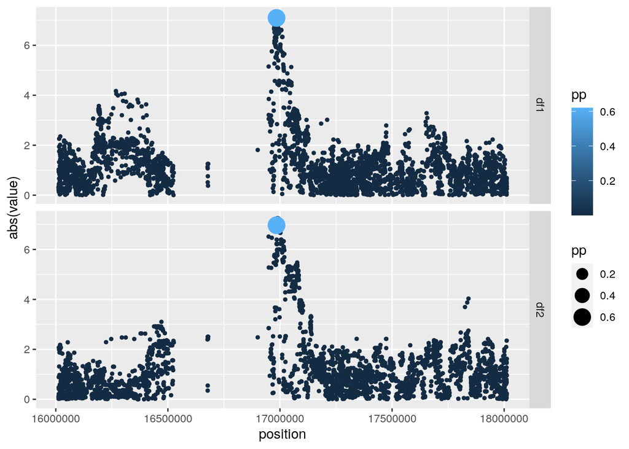

```r
plot(my.res)
```

### Betas $\beta$

Vamos a seguir con los análisis de colocalización cambiando el método de análisis por medio de las betas $\beta$. Utilizamos las dos listas que generamos en el **tema 4** (**gwas.d2** y **eqtl.d2**).

```r
my.res.bvar <- coloc.abf(dataset1 = gwas.d2, dataset2 = eqtl.d2)
```

```
## PP.H0.abf PP.H1.abf PP.H2.abf PP.H3.abf PP.H4.abf
##  1.88e-15  1.23e-09  4.81e-08  3.04e-02  9.70e-01
## [1] "PP abf for shared variant: 97%"
```

#### Resultados de análisis

Resultados de análisis de colocalización de los rasgos 1 y 2 por método de Betas.

```r
print(my.res.bvar)
```

```
##    p1    p2   p12
## 1e-04 1e-04 1e-05
##        H0     H1     H2       H3      H4
##  0.092947 0.3676 0.3676 0.135093 0.03676
##        nsnps           H0           H1           H2           H3           H4
## 3.676000e+03 1.884775e-15 1.227796e-09 4.814382e-08 3.039265e-02 9.696073e-01
```

#### Plot

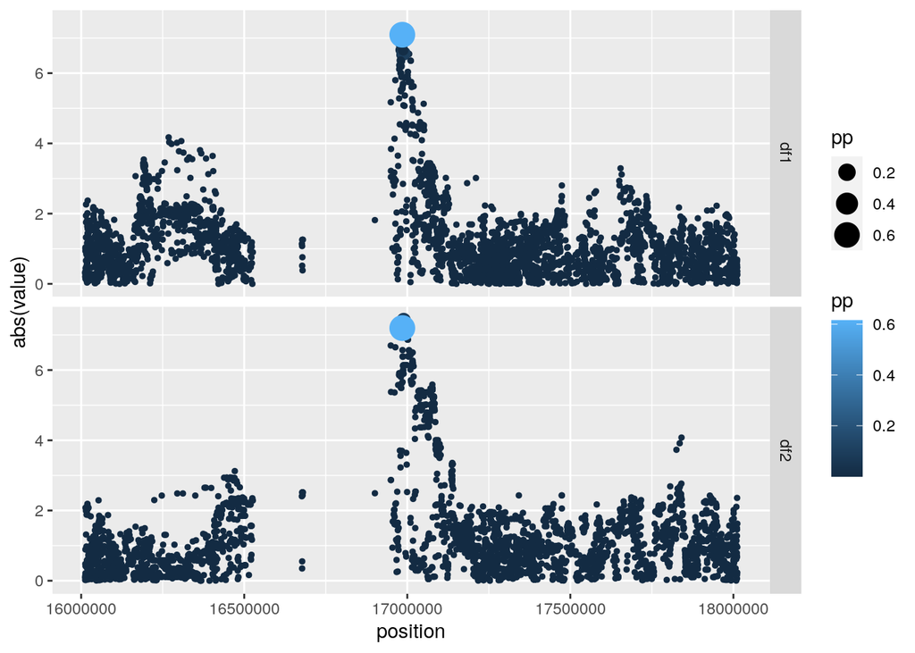

```r
plot(my.res.bvar)
```

```r
print(subset(my.res$results, SNP.PP.H4 > 0.1))

print(subset(my.res.bvar$results, SNP.PP.H4>0.1))
```

| snp | position | pvalues.df1 | MAF.df1 | N.df1 | V.df1 | z.df1 | r.df1 | lABF.df1 | pvalues.df2 | MAF.df2 | N.df2 | V.df2 | z.df2 | r.df2 | lABF.df2 | internal.sum.lABF | SNP.PP.H4 |
| --- | --- | --- | --- | --- | --- | --- | --- | --- | --- | --- | --- | --- | --- | --- | --- | --- | --- |
| rs9435734 | 16984695 | 0 | 0.5443 | 50000 | 4.03e-05 | 7.096129 | 0.9982114 | 21.96934 | 0 | 0.4962686 | 392 | 0.0051023 | 6.968658 | 0.8151487 | 18.9486 | 40.91794 | 0.6201555 |

| snp | position | V.df1 | z.df1 | r.df1 | lABF.df1 | V.df2 | z.df2 | r.df2 | lABF.df2 | internal.sum.lABF | SNP.PP.H4 |
| --- | --- | --- | --- | --- | --- | --- | --- | --- | --- | --- | --- |
| rs9435734 | 16984695 | 2.81e-05 | 7.09434 | 0.9987531 | 21.7899 | 0.0001136 | 7.195579 | 0.9949754 | 23.11139 | 44.90129 | 0.6152423 |

## 6. SuSiE para múltiples variables causales, análisis alternativo

En este análisis usamos las series de datos que hicimos con el método de varianza de betas que incluye LD. En este análisis usamos los siguientes elementos:

- **snp**, nombre del marcador en las dos bases de datos.
- **beta**, valor de beta $\beta$.
- **varbeta**, varianza de la beta $\beta$. $(se\beta)^2$
- **position**, posición del marcador.
- **type**, especificamos `'quant'` para rasgos continuos.
- **N**, tamaño de la muestra.
- **LD**, matriz de DL (**Se va a utilizar**).
- **sdY**, Desviación estándar de $Y$.
- **MAF**, frecuencia del alelo de efecto.
- **cc**, indica casos y controles.

Ejecutamos SuSiE en cada dataset.

```r
eqtl.s <- runsusie(eqtl.d2)

gwas.s <- runsusie(gwas.d2)
```

Graficamos cada dataset resaltando cada grupo de SNPs creíbles.

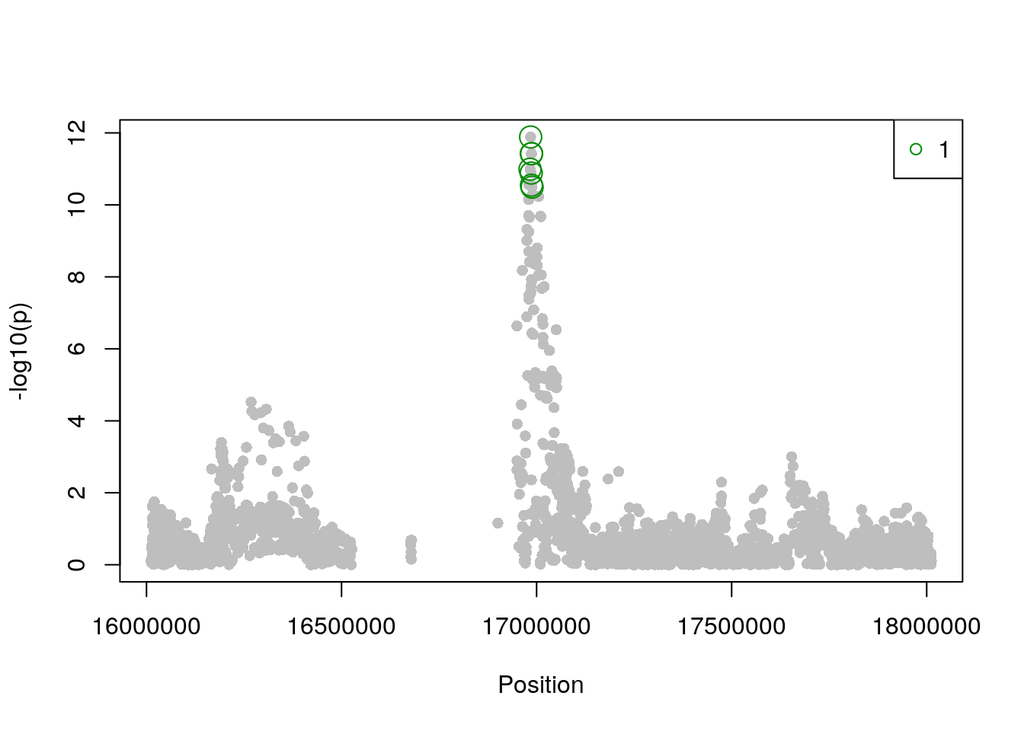

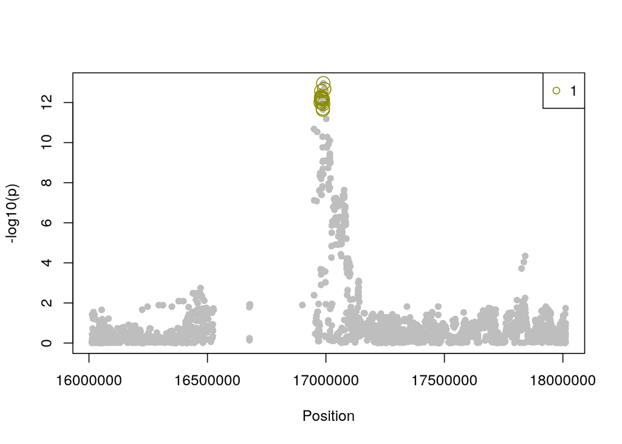

```r
plot_dataset(gwas.d2, susie_obj = gwas.s, color = c("green4"))

plot_dataset(eqtl.d2, susie_obj = eqtl.s, color = c("yellow4"))
```

Ejecutamos `coloc.susie()` para colocalizar cada par de señales.

```r
susie.res <- coloc.susie(gwas.s, eqtl.s)
```

```r
susie.res$summary
```

| nsnps | hit1 | hit2 | PP.H0.abf | PP.H1.abf | PP.H2.abf | PP.H3.abf | PP.H4.abf | idx1 | idx2 |
| --- | --- | --- | --- | --- | --- | --- | --- | --- | --- |
| 3676 | rs9435734 | rs4920605 | 0 | 1e-07 | 0 | 0.0489867 | 0.9510132 | 1 | 1 |

```r
print(subset(susie.res$results, SNP.PP.H4.abf > 0.05))
```

| snp | SNP.PP.H4.abf |
| --- | --- |
| rs3754512 | 0.0504210 |
| rs9435734 | 0.6763006 |
| rs2076605 | 0.0852892 |
| rs761421 | 0.0782490 |

Realizamos análisis de sensibilidad con los cuales graficaremos las señales que queremos considerar. Para eso, graficaremos **Manhattan plots** y **probabilidades** para cada señal.

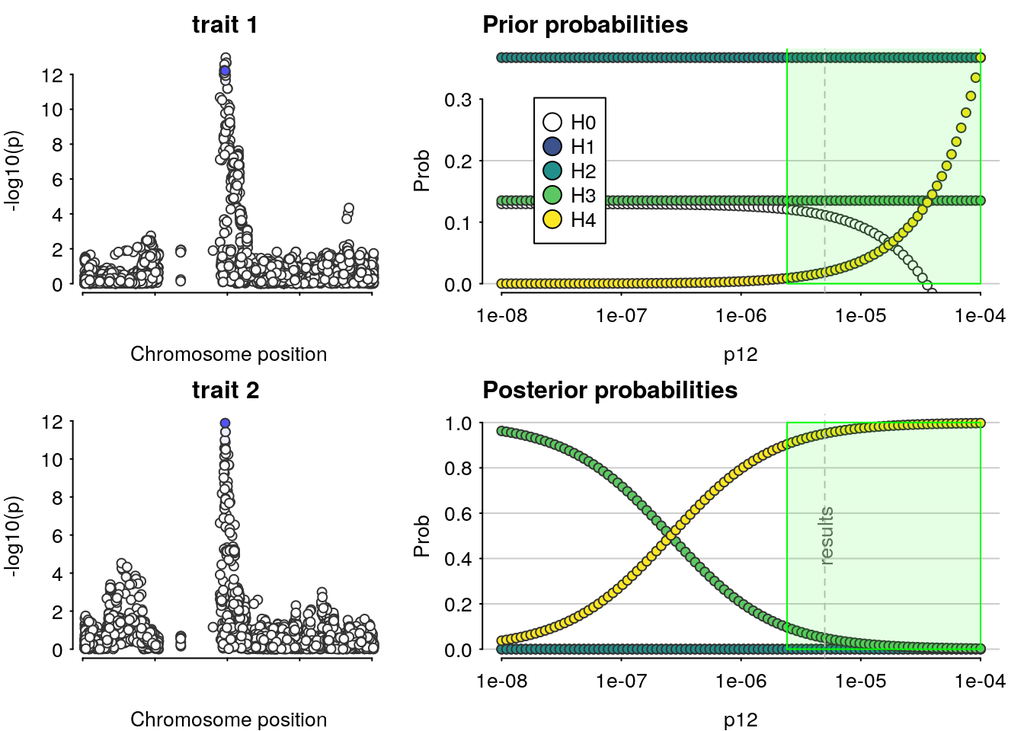

```r
sensitivity(susie.res, "H4 > 0.9", row=1, dataset1 = eqtl.d2, dataset2 = gwas.d2)
```

## 7. Guardamos los resultados y gráficas de nuestros análisis

Basado en el método de *P-values*:

- Guardamos los resultados si **H4** tiene la probabilidad posterior más alta.
- Guardamos los resultados si los valores del SNP.PP.H4 >0.01.
- Guardamos el gráfico `coloc.abf`.

```r
# Generamos un algoritmo condicional IF-ELSE

# Queremos probar si PP.H4.abf es igual al valor máximo de los resultados -1.
if(my.res$summary['PP.H4.abf'] == max(my.res$summary[-1])) {

  # En caso de que se cumpla el criterio, guardamos los resultados.
    write.table(my.res$summary,
                paste0(trait1, '.', trait2, '.coloc_abf_gene.pval.txt'),
                col.names=T, row.names=F, sep='\t', quote=F)

  # Guardamos todos los valores cuyo SNP.PP.H4 sea mayor a 0.01.
    write.table(subset(my.res$results,SNP.PP.H4>0.01),
                paste0(trait1, '.', trait2, '.coloc_abf_snp.pval.txt'),
                col.names=T, row.names=F, sep='\t', quote=F)
    }

# Generamos un archivo `.png` donde se guarde el grpafico.
png("Height.eqtl.coloc_pvalues.png")
plot(my.res)
dev.off()
```

Basado en el método de *Betas* $\beta$:

- Guardamos los resultados si **H4** tiene la probabilidad posterior más alta.
- Guardamos los resultados si los valores del SNP.PP.H4 >0.01.
- Guardamos el gráfico `coloc.abf`.

```r
if(my.res.bvar$summary['PP.H4.abf'] == max(my.res.bvar$summary[-1])) {
    write.table(
      my.res.bvar$summary,
      paste0(trait1, '.', trait2, '.coloc_abf_gene.betas.txt'),
      col.names=T, row.names=F, sep='\t', quote=F)

    write.table(
      subset(my.res.bvar$results, SNP.PP.H4 > 0.01),
      paste0(trait1, '.', trait2, '.coloc_abf_snp.betas.txt'),
      col.names=T, row.names=F, sep='\t', quote=F)
    }

png("Height.eqtl.coloc_betas.png")
plot(my.res.bvar)
dev.off()
```

Basado en el método *SuSiE* :

- Guardamos los resultados si **H4** tiene la probabilidad posterior más alta, `coloc-susie` (>1 causal variant).
- Guardamos los resultados si los valores del SNP.PP.H4 >0.01, `coloc-susie` (>1 causal variant).
- Guardamos los gráficos de cada data set que incluyan los resultados de `runsusie`.
- Guardamos los Manhattan-plots y probabilidades de cada señal.

```r
write.table(susie.res$summary,
            paste0(trait1, '.', trait2, '.coloc_susie_abf_gene.txt'),
            col.names=T, row.names=F, sep='\t', quote=F)

write.table(subset(susie.res$results, SNP.PP.H4.abf > 0.01),
            paste0(trait1, '.', trait2, '.coloc_susie_abf_snp.txt'),
            col.names=T, row.names=F, sep='\t', quote=F)

png("Height.gwas.susie_obj.png")
plot_dataset(gwas.d2,susie_obj=gwas.s,color = c("green4"))
dev.off()

png("Height.eqtl.susie_obj.png")
plot_dataset(eqtl.d2,susie_obj=eqtl.s,color = c("yellow4"))
dev.off()

png("Height.gwas.eqtl.susie_probs.png")
sensitivity(susie.res,"H4 > 0.9",
            row=1,
            dataset1 = eqtl.d2,
            dataset2 = gwas.d2)
dev.off()
```

Workshop de Colocalización genética. Código y documento original, Misa Graff. Traducción, Carlos González-Carballo. Unidad de Investigación en Medicina Experimental, UNAM.